# Gravestones at the Westhampton Memorial Graveyard

## Exploratory Analysis

Firstly, I was interested in exploring the relationship between the year of birth and the lifespan of the individual, as it is commonly known that lifespans have generally had an increasing trend due largely to the introduction of modern medicine and other social factors in recent centuries. To accomplish this, I have plotted the birth years of the individuals in the data set against their age at death, as seen below:

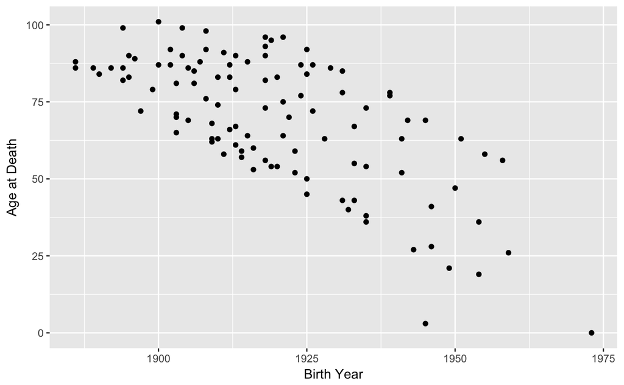

This graph was surprising to me, because it seems that the trend is actually moving opposite to what one would expect. However, this data set is such a small sample with a very limited range of birth years, so any conclusions about what is generally happening in the population in relation to lifespan change over time would be difficult to support.

I was then interested to explore the relationship between sex and the lifespan of the individual. Do males or females generally live longer than the opposite sex among those buried in Westhampton Memorial Graveyard, or is there no apparent difference between the lifespan of males and females in this dataset?

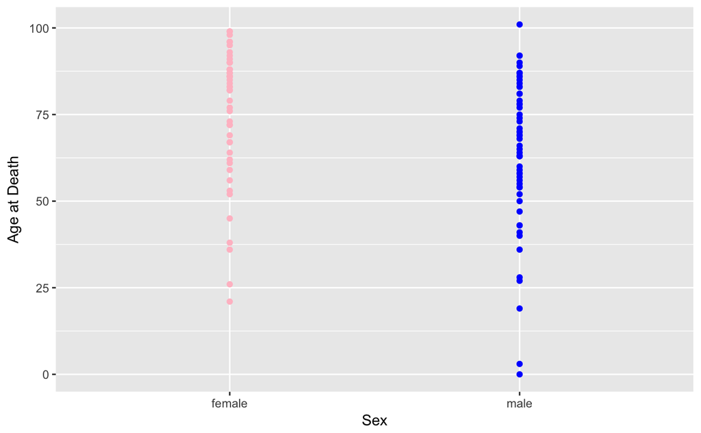

From simply looking at the graph, it is difficult to answer the questions posed above. To help with the analysis of this graph, the average lifespan of each sex is calculated below.

Average female lifespan:

```
[1] 75.72917
```

Average male lifespan:

```
[1] 64.15
```

From this, we can conclude that the average female lifespan in the dataset is approximately 11.58 years greater than that of the average male lifespan in the dataset. According to the limited sample of data collected, females buried in the Westhampton Memorial Graveyard generally live a longer life than males buried in the Westhampton Memorial Graveyard.